# **Week 12: Plotting and Visualization using Matplotlib**

please refer to the textbook: "Python for Data Analysis" by Wes McKinney for details of this topic (**Chapter 9**)

### **Load Matplotlib library**

```python
# Load library
import matplotlib.pyplot as plt
import matplotlib.patches as patches
import numpy as np
import pandas as pd
import seaborn as sns
```

### Histogram

- **`bins`**: Bins are the intervals into which the data is divided for counting and display in the histogram.
  - Having 20 bins means the data range will be split into 20 intervals
- **`alpha`**: controls the transparency of the bars.
  - A value of 1.0 would be completely opaque, while 0.0 would be completely transparent.

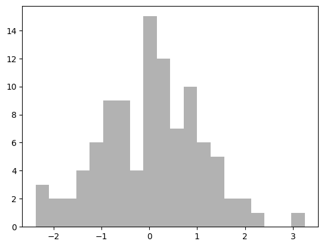

```python
# Histogram - plot 1
rng = np.random.RandomState(12345) #set.seed()
plt.hist(rng.standard_normal(100), bins=20, color='black',
         alpha=0.3); # ; will only show the plot
```

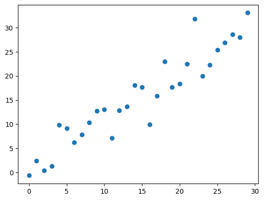

```python
# Scatter plot - plot 2
rng = np.random.RandomState(12345)
plt.scatter(np.arange(30), np.arange(30) +
            3 * rng.standard_normal(30));
```

### **linestyle**

1. some other options for the linestyle argument:
- `'-'` (**solid**): This is the default linestyle and creates a solid line.
- `'--'` (**dashed**): Creates a dashed line.
- `'-.'` (**dash-dot**): Creates a line with alternating dashes and dots.
- `':'` (**dotted**): Creates a dotted line.
- `'**None**'` or `' '` or `''` (no line): This will plot only markers if specified, or no line at all.
2. we can also use the shorter codes for these linestyles:
- **`solid`**: `-`
- **`dashed`**: `--`
- **`dashdot`**: `-.`
- **`dotted`**: `:`

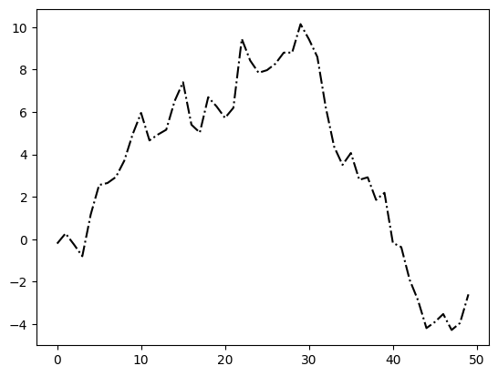

```python
# Line plot : plot 3
rng = np.random.RandomState(12345)
plt.plot(rng.standard_normal(50).cumsum(),
         color='black', linestyle='-.');
```

### **Place all the subplots into one panel**

1. **plt.figure()** - create a new figure
2. **add_subplot** - to create one or more subplots
3. **Subplots** are numbered sequentially **starting from 1, going from left to right and top to bottom.** - a **(2, 2, 1)** argument means we're adding the first subplot (top-left corner) in the 2x2 grid.

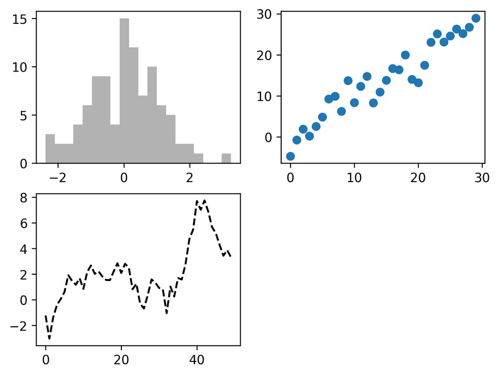

```python
# Create one or more subplots
# 2 x 2; 4 plots in total
# Plot axis
rng = np.random.RandomState(12345)
fig = plt.figure(dpi=300) # dpi = resolution (dots per inch)
ax1 = fig.add_subplot(2, 2, 1)
ax2 = fig.add_subplot(2, 2, 2)
ax3 = fig.add_subplot(2, 2, 3)
ax1.hist(rng.standard_normal(100), bins=20, color='black', alpha=0.3);
ax2.scatter(np.arange(30), np.arange(30) + 3 * rng.standard_normal(30));
ax3.plot(rng.standard_normal(50).cumsum(), color='black', linestyle='dashed');

# To save the figures
# plt.savefig('/content/drive/MyDrive/aliabu/combi3.pdf') - google colab
plt.savefig('./Output/combi3.pdf')
```

### **Adjusting the spacing around subplots**

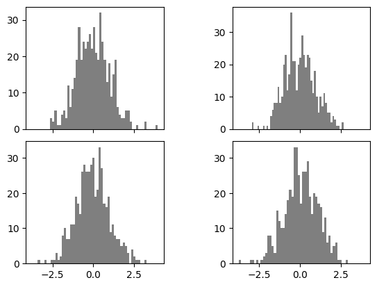

```python
# An example that shrink the spacing of the subplots to zero
# Change the value of wspace and hspace
rng = np.random.RandomState(12345)
fig, axes = plt.subplots(2, 2, sharex=True, sharey=False)

# Using a nested loop to populate 2x2 grid
for i in range(2):
    for j in range(2):
        axes[i, j].hist(rng.standard_normal(500), bins=50,
                        color='black', alpha=0.5)

# Adjusting the spacing
fig.subplots_adjust(wspace=0.5, hspace=0.1)
```

### **Colors, Markers, and Line Styles**

1. specify line styles using plt.plot documentation (**plt.plot?**)
2. specify color using hex code, e.g. **"#CECECE"**
3. For more information, can visit this website: https://htmlcolorcodes.com/

### **Marker**

specify a symbol or shape that will be placed at each data point on the plotted line

### **Other Marker Options**

Matplotlib offers a wide variety of marker options. Here are a few examples:

- `'.'`: Point
- `','`: Pixel
- `'o'`: Circle
- `'v'`: Triangle down
- `'^'`: Triangle up
- `'<'`: Triangle left
- `'>'`: Triangle right
- `'s'`: Square
- `'+'`: Plus
- `'x'`: X
- `'D'`: Diamond
- `'d'`: Thin diamond
- `'|'`: Vertical line
- `'_'`: Horizontal line

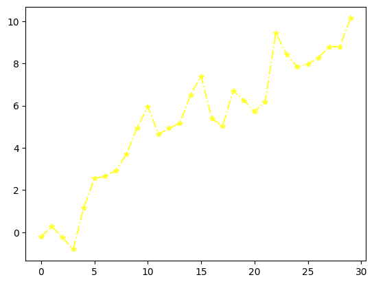

```python
# Adding marker on line plot
rng = np.random.RandomState(12345)
plt.plot(rng.standard_normal(30).cumsum(), color='#ffff33',
        linestyle='-.', marker='*');
```

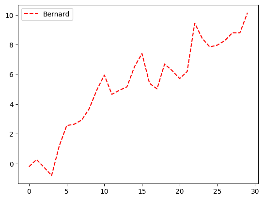

```python
# Drawstyle default
rng = np.random.RandomState(12345)
data = rng.standard_normal(30).cumsum()
plt.plot(data, color='r', linestyle='dashed', label='Bernard')
plt.legend();
```

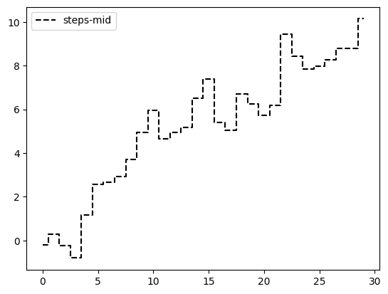

```python
# Drawstyle steps-mid
plt.plot(data, color='black', linestyle='dashed',
         drawstyle='steps-mid', label='steps-mid')
plt.legend();
```

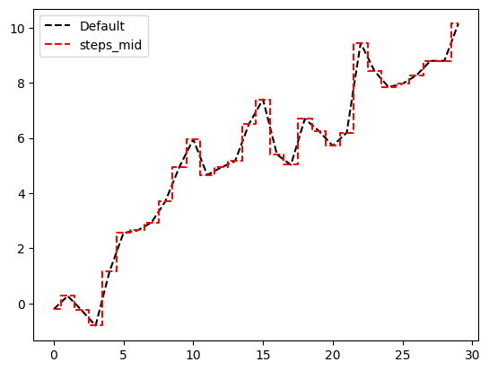

```python
# Combine
plt.plot(data, color='black', linestyle='dashed', label='Default')
plt.plot(data, color='red', linestyle='dashed',
         drawstyle='steps-mid', label='steps_mid')
plt.legend();
#plt.savefig('/content/drive/MyDrive/lines.pdf', dpi=300)
plt.savefig('./Output/lines.pdf', dpi=300)
```

### **Ticks, Labels, and Legends**

1. parameter such as **xlim([0, 10])** sets the x-xis range from **0 to 10**

### **Setting the title, axis labels, ticks, and tick labels**

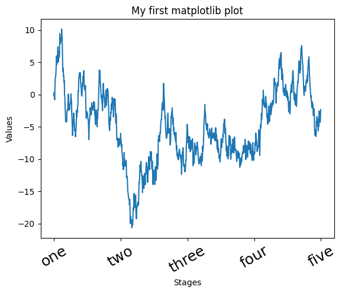

```python
# An example
rng = np.random.RandomState(12345)
fig, ax = plt.subplots()
ax.plot(rng.standard_normal(1000).cumsum())

# Changex x-axis ticks annotation
ax.set_xticks([0, 250, 500, 750, 1000])

# Cabel the x-axis ticks with names
ax.set_xticklabels(['one', 'two', 'three', 'four', 'five'],
                   rotation=30, fontsize=18)
ax.set_xlabel('Stages')
ax.set_ylabel('Values')
ax.set_title('My first matplotlib plot');
```

### **Adding Legends**

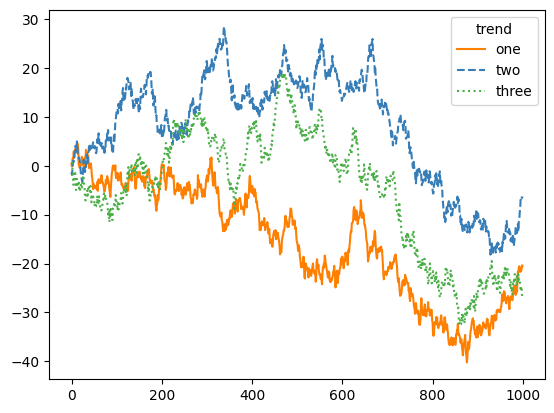

```python
# Adding legend
fig, ax = plt.subplots()
ax.plot(np.random.randn(1000).cumsum(), color='#FF7F00', label='one')
ax.plot(np.random.randn(1000).cumsum(), color='#377EB8', linestyle='dashed',
        label='two')
ax.plot(np.random.randn(1000).cumsum(), color='#4DAF4A', linestyle='dotted',
        label='three')
ax.legend(title='trend');
```

### **Annotations and Drawing on a Subplot**

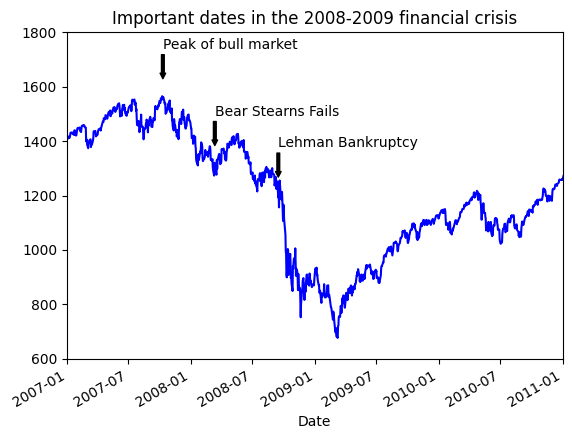

```python
# The SPX data
from datetime import datetime

fig, ax = plt.subplots()

data = pd.read_csv('https://bit.ly/3iofIY8', index_col=0, parse_dates=True)
spx = data['SPX']

spx.plot(ax=ax, color='blue')

crisis_data = [
    (datetime(2007, 10, 11), 'Peak of bull market'),
    (datetime(2008, 3, 12), 'Bear Stearns Fails'),
    (datetime(2008, 9, 15), 'Lehman Bankruptcy')
]

for date, label in crisis_data:
    ax.annotate(label, xy=(date, spx.asof(date) + 75),
                xytext=(date, spx.asof(date) + 225),
                arrowprops=dict(facecolor='black', headwidth=4, width=2,
                                headlength=4),
                horizontalalignment='left', verticalalignment='top')

# # Zoom in on 2007-2010
ax.set_xlim(['1/1/2007', '1/1/2011'])
ax.set_ylim([600, 1800])
ax.set_title('Important dates in the 2008-2009 financial crisis');
```

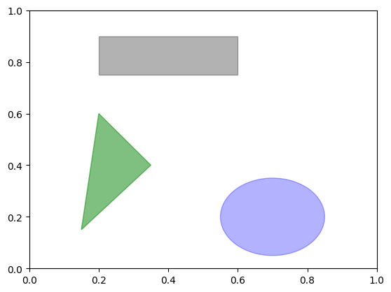

```python
# Adding shapes to the same plot
fig, ax = plt.subplots()

rect = plt.Rectangle((0.2, 0.75), 0.4, 0.15, color='black', alpha=0.3)
circ = plt.Circle((0.7, 0.2), 0.15, color='blue', alpha=0.3)
pgon = plt.Polygon([[0.15, 0.15], [0.35, 0.4], [0.2, 0.6]],
                   color='green', alpha=0.5)

ax.add_patch(rect)
ax.add_patch(circ)
ax.add_patch(pgon);
```

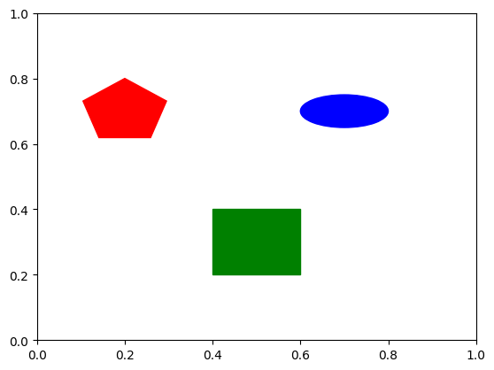

```python
# Challenge: plot a pentagon, ellipse, square figures in the exact same figure
fig, ax = plt.subplots()

# Pentagon
pentagon = patches.RegularPolygon((0.2, 0.7), 5, radius=0.1, color='red')  # Center, sides, radius
ax.add_patch(pentagon)

# Ellipse
ellipse = patches.Ellipse((0.7, 0.7), 0.2, 0.1, color='blue')  # Center, width, height
ax.add_patch(ellipse)

# Square
square = patches.Rectangle((0.4, 0.2), 0.2, 0.2, color='green')  # Lower-left, width, height
ax.add_patch(square)

plt.show()  # Display the figure
```

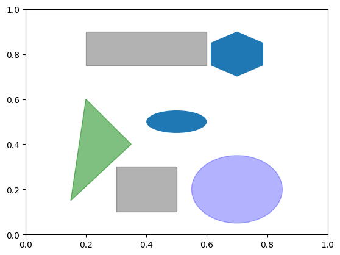

```python
# Adding shapes to a plot
import matplotlib.patches as mpatches
fig, ax = plt.subplots()

rect = plt.Rectangle((0.2, 0.75), 0.4, 0.15, color='black', alpha=0.3)
circ = plt.Circle((0.7, 0.2), 0.15, color='blue', alpha=0.3)
pgon = plt.Polygon([[0.15, 0.15], [0.35, 0.4], [0.2, 0.6]],
                   color='green', alpha=0.5)
sqr = plt.Rectangle((0.3, 0.1), 0.2, 0.2, color='black', alpha=0.3)

# Add ellipse
ellipse = mpatches.Ellipse((0.5,0.5), 0.2, 0.1)

# Add regular hex
hex = mpatches.RegularPolygon((0.7,0.8), 6, radius=0.1)

ax.add_patch(rect)
ax.add_patch(circ)
ax.add_patch(pgon)
ax.add_patch(sqr)
ax.add_patch(ellipse)
ax.add_patch(hex);
```

```python
# To find more information of the shapes
#plt.Rectangle?
#plt.Circle?
#plt.Polygon?
```

### **Saving Plots to File**

1. File format: '**.png**','**.pdf**','**.svg**','**.ps**','**.eps**', .etc

```python
# Saving the plot
#fig.savefig('/content/drive/MyDrive/STQD6014_Executive/_SEM1_20242025/Figures/shapes.jpeg', dpi=400)
fig.savefig('./Output/shapes.jpeg', dpi=400)
```

### **Matplotlib Configuration**

using **rc** method

1. plt.rc('figure', figsize=(10, 10)) - to set the global default figure size to be 10 × 10
2. plt.rcdefaults() - restored to default values

```python
# Challenge 1: To set the previous shapes figure to 5 x 5
plt.rc('figure', figsize=(5, 5))
```

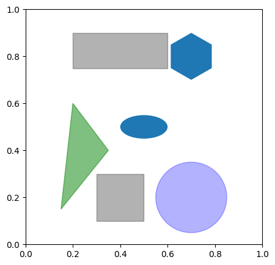

```python
# Adding shapes to a plot : Attention
import matplotlib.patches as mpatches
fig, ax = plt.subplots()

rect = plt.Rectangle((0.2, 0.75), 0.4, 0.15, color='black', alpha=0.3)
circ = plt.Circle((0.7, 0.2), 0.15, color='blue', alpha=0.3)
pgon = plt.Polygon([[0.15, 0.15], [0.35, 0.4], [0.2, 0.6]],
                   color='green', alpha=0.5)
sqr = plt.Rectangle((0.3, 0.1), 0.2, 0.2, color='black', alpha=0.3)

# Add ellipse
ellipse = mpatches.Ellipse((0.5,0.5),0.2,0.1)

# Add regular hex
hex = mpatches.RegularPolygon((0.7,0.8),6, radius=0.1)

ax.add_patch(rect)
ax.add_patch(circ)
ax.add_patch(pgon)
ax.add_patch(sqr)
ax.add_patch(ellipse)
ax.add_patch(hex);
```

```python
# Reset to default value
plt.rcdefaults()
```

## **Plotting with pandas and seaborn**

**seaborn** is a high-level **statistical graphics library** built on matplotlib.

seaborn simplifies creating many common visualization types.

### **Line plots**

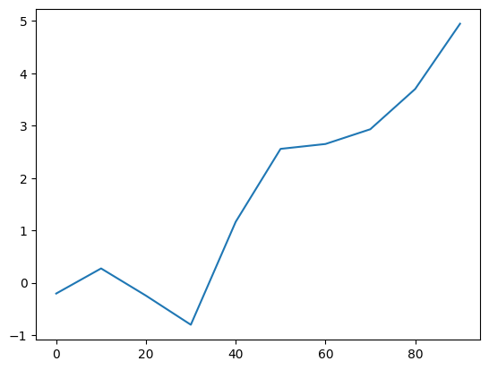

```python
# Using series data
rng = np.random.RandomState(12345)
s = pd.Series(rng.standard_normal(10).cumsum(),
              index=np.arange(0, 100, 10))
s.plot();
```

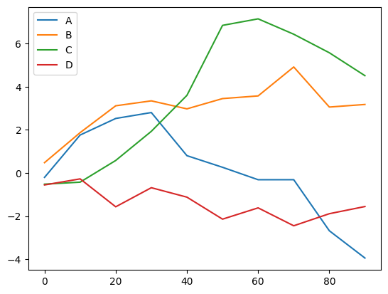

```python
# Using Dataframe
rng = np.random.RandomState(12345)
df = pd.DataFrame(rng.standard_normal((10, 4)).cumsum(0),
                  columns=['A', 'B', 'C', 'D'],
                  index=np.arange(0, 100, 10))
df.plot();
```

```python
# Show df content
df
```

|  | A | B | C | D |
| --- | --- | --- | --- | --- |
| 0 | -0.204708 | 0.478943 | -0.519439 | -0.555730 |
| 10 | 1.761073 | 1.872349 | -0.426531 | -0.273984 |
| 20 | 2.530095 | 3.118784 | 0.580659 | -1.570205 |
| 30 | 2.805087 | 3.347697 | 1.933575 | -0.683776 |
| 40 | 0.803450 | 2.975854 | 3.602601 | -1.122346 |
| 50 | 0.263708 | 3.452839 | 6.851545 | -2.143573 |
| 60 | -0.313379 | 3.576961 | 7.154158 | -1.619801 |
| 70 | -0.312439 | 4.920770 | 6.440614 | -2.450955 |
| 80 | -2.682670 | 3.060010 | 5.579857 | -1.890809 |
| 90 | -3.948605 | 3.179837 | 4.516344 | -1.557927 |

### **Bar plots**

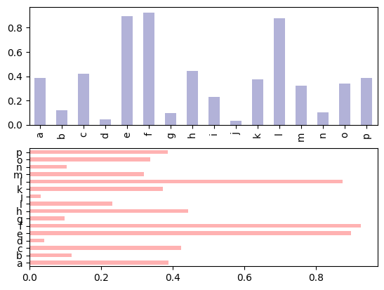

```python
# Series data
fig, axes = plt.subplots(2, 1)
data = pd.Series(np.random.uniform(size=16), index=list('abcdefghijklmnop'))

# Plot.bar is for plotting vertical bar
data.plot.bar(ax=axes[0], color='navy', alpha=0.3)

# Plot.barh is for plotting horizontal bar
data.plot.barh(ax=axes[1], color='red', alpha=0.3);
```

```python
# Example DataFrame
df = pd.DataFrame(np.random.uniform(size=(6, 4)),
                  index=['one', 'two', 'three', 'four', 'five', 'six'],
                  columns=pd.Index(['A', 'B', 'C', 'D'], name='Genus'))
df
```

| Genus | A | B | C | D |
| --- | --- | --- | --- | --- |
| one | 0.715885 | 0.167505 | 0.371184 | 0.077939 |
| two | 0.734025 | 0.475724 | 0.960029 | 0.974574 |
| three | 0.745200 | 0.764236 | 0.446462 | 0.803392 |
| four | 0.816995 | 0.407603 | 0.146228 | 0.938993 |
| five | 0.152856 | 0.439007 | 0.485293 | 0.895518 |
| six | 0.041555 | 0.593589 | 0.344715 | 0.846730 |

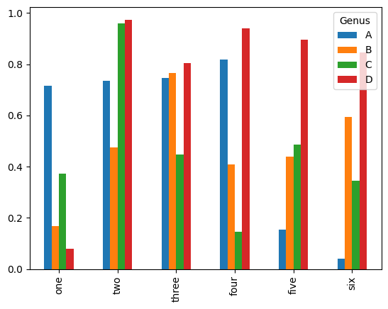

```python
# Bar plot
df.plot.bar();
```

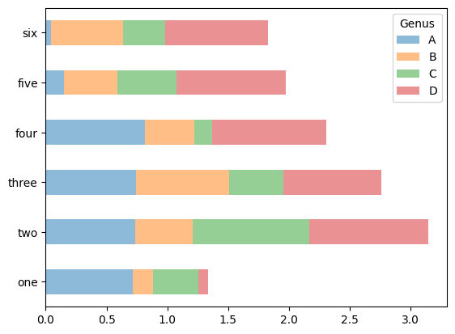

```python
# Stacked bar plots
df.plot.barh(stacked=True, alpha=0.5);
```

```python
# A dataset about restaurant tipping
tips = pd.read_csv('https://bit.ly/3jCROII')
```

```python
# Show tips content
tips
```

|  | total_bill | tip | smoker | day | time | size |
| --- | --- | --- | --- | --- | --- | --- |
| 0 | 16.99 | 1.01 | No | Sun | Dinner | 2 |
| 1 | 10.34 | 1.66 | No | Sun | Dinner | 3 |
| 2 | 21.01 | 3.50 | No | Sun | Dinner | 3 |
| 3 | 23.68 | 3.31 | No | Sun | Dinner | 2 |
| 4 | 24.59 | 3.61 | No | Sun | Dinner | 4 |
| ... | ... | ... | ... | ... | ... | ... |
| 239 | 29.03 | 5.92 | No | Sat | Dinner | 3 |
| 240 | 27.18 | 2.00 | Yes | Sat | Dinner | 2 |
| 241 | 22.67 | 2.00 | Yes | Sat | Dinner | 2 |
| 242 | 17.82 | 1.75 | No | Sat | Dinner | 2 |
| 243 | 18.78 | 3.00 | No | Thur | Dinner | 2 |

244 rows × 6 columns

```python
# Create a frequency table
party_counts = pd.crosstab(tips['day'], tips['size'], margins=True)
party_counts
```

| size day | 1 | 2 | 3 | 4 | 5 | 6 | All |
| --- | --- | --- | --- | --- | --- | --- | --- |
| Fri | 1 | 16 | 1 | 1 | 0 | 0 | 19 |
| Sat | 2 | 53 | 18 | 13 | 1 | 0 | 87 |
| Sun | 0 | 39 | 15 | 18 | 3 | 1 | 76 |
| Thur | 1 | 48 | 4 | 5 | 1 | 3 | 62 |
| All | 4 | 156 | 38 | 37 | 5 | 4 | 244 |

```python
# Reorder the index
party_counts = party_counts.reindex(index=['Thur', 'Fri', 'Sat', 'Sun'])
party_counts
```

| size day | 1 | 2 | 3 | 4 | 5 | 6 | All |
| --- | --- | --- | --- | --- | --- | --- | --- |
| Thur | 1 | 48 | 4 | 5 | 1 | 3 | 62 |
| Fri | 1 | 16 | 1 | 1 | 0 | 0 | 19 |
| Sat | 2 | 53 | 18 | 13 | 1 | 0 | 87 |
| Sun | 0 | 39 | 15 | 18 | 3 | 1 | 76 |

```python
# Extract party_count from col 2 to 5
party_counts = party_counts.loc[:, 2:5]
```

```python
# Show content for party_counts
party_counts
```

| size day | 2 | 3 | 4 | 5 |
| --- | --- | --- | --- | --- |
| Thur | 48 | 4 | 5 | 1 |
| Fri | 16 | 1 | 1 | 0 |
| Sat | 53 | 18 | 13 | 1 |
| Sun | 39 | 15 | 18 | 3 |

```python
# Normalize each row to sum to 1
party_pcts = party_counts.div(party_counts.sum(axis='columns'),
                              axis='index')
party_pcts
```

| size day | 2 | 3 | 4 | 5 |
| --- | --- | --- | --- | --- |
| Thur | 0.827586 | 0.068966 | 0.086207 | 0.017241 |
| Fri | 0.888889 | 0.055556 | 0.055556 | 0.000000 |
| Sat | 0.623529 | 0.211765 | 0.152941 | 0.011765 |
| Sun | 0.520000 | 0.200000 | 0.240000 | 0.040000 |

```python
# To check documentation for div() function
party_counts.div?
```

[output not shown]

[output cut: 120 more lines]

[output not shown]

```python
# Manually check the vaue
4/58
```

```
0.06896551724137931
```

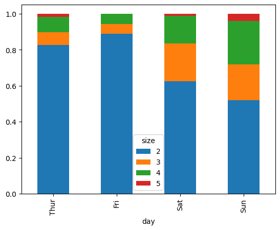

```python
# Stacked bar plot
party_pcts.plot.bar(stacked=True);
```

### **Using seaborn package**

```python
# Import Seaborn package
import seaborn as sns
```

```python
# Show content for tips
tips
```

|  | total_bill | tip | smoker | day | time | size |
| --- | --- | --- | --- | --- | --- | --- |
| 0 | 16.99 | 1.01 | No | Sun | Dinner | 2 |
| 1 | 10.34 | 1.66 | No | Sun | Dinner | 3 |
| 2 | 21.01 | 3.50 | No | Sun | Dinner | 3 |
| 3 | 23.68 | 3.31 | No | Sun | Dinner | 2 |
| 4 | 24.59 | 3.61 | No | Sun | Dinner | 4 |
| ... | ... | ... | ... | ... | ... | ... |
| 239 | 29.03 | 5.92 | No | Sat | Dinner | 3 |
| 240 | 27.18 | 2.00 | Yes | Sat | Dinner | 2 |
| 241 | 22.67 | 2.00 | Yes | Sat | Dinner | 2 |
| 242 | 17.82 | 1.75 | No | Sat | Dinner | 2 |
| 243 | 18.78 | 3.00 | No | Thur | Dinner | 2 |

244 rows × 6 columns

```python
# Add a new column for 'tip_pct'
tips['tip_pct'] = tips['tip'] / (tips['total_bill'] - tips['tip'])
```

```python
# Show top five rows
tips.head()
```

|  | total_bill | tip | smoker | day | time | size | tip_pct |
| --- | --- | --- | --- | --- | --- | --- | --- |
| 0 | 16.99 | 1.01 | No | Sun | Dinner | 2 | 0.063204 |
| 1 | 10.34 | 1.66 | No | Sun | Dinner | 3 | 0.191244 |
| 2 | 21.01 | 3.50 | No | Sun | Dinner | 3 | 0.199886 |
| 3 | 23.68 | 3.31 | No | Sun | Dinner | 2 | 0.162494 |
| 4 | 24.59 | 3.61 | No | Sun | Dinner | 4 | 0.172069 |

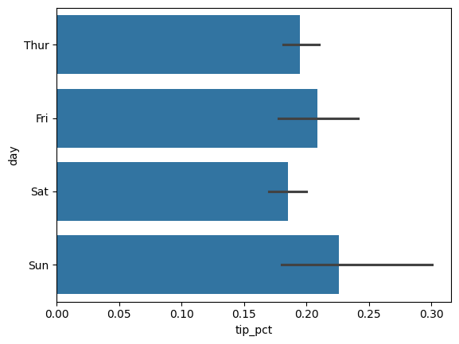

```python
# Using black lines on the bars to represent 95% confidence interval
sns.barplot(x='tip_pct', y='day', data=tips, orient='h',
            order=['Thur', 'Fri', 'Sat', 'Sun']);
```

### **`hue`**

- `hue` helps to visualize the impact of an **additional categorical variable** on our main comparison.

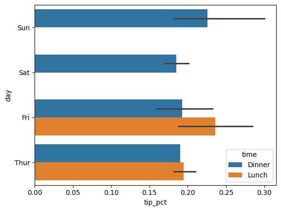

```python
# Using hue to add a categorical distinction
sns.barplot(x='tip_pct', y='day', hue='time', data=tips, orient='h',
            order=['Sun', 'Sat', 'Fri', 'Thur']);
```

```python
# To check documentation for sns.barplot
sns.barplot?
```

[output not shown]

[output cut: 151 more lines]

[output not shown]

```python
# Display contents for tips
tips
```

|  | total_bill | tip | smoker | day | time | size | tip_pct |
| --- | --- | --- | --- | --- | --- | --- | --- |
| 0 | 16.99 | 1.01 | No | Sun | Dinner | 2 | 0.063204 |
| 1 | 10.34 | 1.66 | No | Sun | Dinner | 3 | 0.191244 |
| 2 | 21.01 | 3.50 | No | Sun | Dinner | 3 | 0.199886 |
| 3 | 23.68 | 3.31 | No | Sun | Dinner | 2 | 0.162494 |
| 4 | 24.59 | 3.61 | No | Sun | Dinner | 4 | 0.172069 |
| ... | ... | ... | ... | ... | ... | ... | ... |
| 239 | 29.03 | 5.92 | No | Sat | Dinner | 3 | 0.256166 |
| 240 | 27.18 | 2.00 | Yes | Sat | Dinner | 2 | 0.079428 |
| 241 | 22.67 | 2.00 | Yes | Sat | Dinner | 2 | 0.096759 |
| 242 | 17.82 | 1.75 | No | Sat | Dinner | 2 | 0.108899 |
| 243 | 18.78 | 3.00 | No | Thur | Dinner | 2 | 0.190114 |

244 rows × 7 columns

### **Histograms and Density Plots**

discretized display of **value frequency**

```python
# Display top few rows
tips.head()
```

|  | total_bill | tip | smoker | day | time | size | tip_pct |
| --- | --- | --- | --- | --- | --- | --- | --- |
| 0 | 16.99 | 1.01 | No | Sun | Dinner | 2 | 0.063204 |
| 1 | 10.34 | 1.66 | No | Sun | Dinner | 3 | 0.191244 |
| 2 | 21.01 | 3.50 | No | Sun | Dinner | 3 | 0.199886 |
| 3 | 23.68 | 3.31 | No | Sun | Dinner | 2 | 0.162494 |
| 4 | 24.59 | 3.61 | No | Sun | Dinner | 4 | 0.172069 |

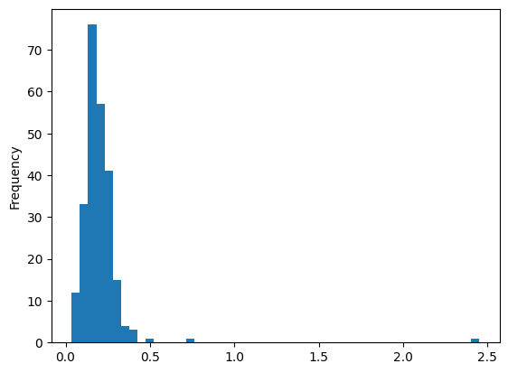

```python
# Histogram
tips['tip_pct'].plot.hist(bins=50);
```

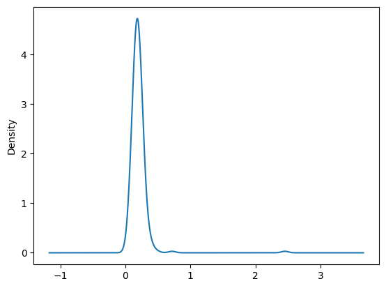

```python
# Density plot
tips['tip_pct'].plot.density();
```

```python
# Example dataset
comp1 = np.random.standard_normal(200)
comp2 = 10 + 2 * np.random.standard_normal(200)
values = pd.Series(np.concatenate([comp1, comp2]))

# Display content for values
values
```

```
0      -0.313559
1      -0.367684
2      -0.034959
3      -0.089517
4      -0.728365
         ...
395    10.421917
396     7.855848
397    12.561823
398     9.259135
399    10.066034
Length: 400, dtype: float64
```

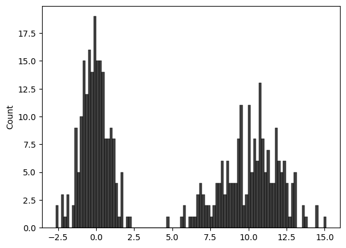

```python
# Plot histogram
sns.histplot(values, bins=100, color='black');
```

### **Scatter or Point Plots**

examining the relationship between two one-dimensional data series

#### **Macro dataset**

- Collection of economic data points that reflect the overall performance and health of a country, region, or the global economy.

```python
# Example macro dataset
macro = pd.read_csv('https://bit.ly/3FYxCYZ')
macro
```

|  | year | quarter | realgdp | realcons | realinv | realgovt | realdpi | cpi | m1 | tbilrate | unemp | pop | infl | realint |
| --- | --- | --- | --- | --- | --- | --- | --- | --- | --- | --- | --- | --- | --- | --- |
| 0 | 1959 | 1 | 2710.349 | 1707.4 | 286.898 | 470.045 | 1886.9 | 28.980 | 139.7 | 2.82 | 5.8 | 177.146 | 0.00 | 0.00 |
| 1 | 1959 | 2 | 2778.801 | 1733.7 | 310.859 | 481.301 | 1919.7 | 29.150 | 141.7 | 3.08 | 5.1 | 177.830 | 2.34 | 0.74 |
| 2 | 1959 | 3 | 2775.488 | 1751.8 | 289.226 | 491.260 | 1916.4 | 29.350 | 140.5 | 3.82 | 5.3 | 178.657 | 2.74 | 1.09 |
| 3 | 1959 | 4 | 2785.204 | 1753.7 | 299.356 | 484.052 | 1931.3 | 29.370 | 140.0 | 4.33 | 5.6 | 179.386 | 0.27 | 4.06 |
| 4 | 1960 | 1 | 2847.699 | 1770.5 | 331.722 | 462.199 | 1955.5 | 29.540 | 139.6 | 3.50 | 5.2 | 180.007 | 2.31 | 1.19 |
| ... | ... | ... | ... | ... | ... | ... | ... | ... | ... | ... | ... | ... | ... | ... |
| 198 | 2008 | 3 | 13324.600 | 9267.7 | 1990.693 | 991.551 | 9838.3 | 216.889 | 1474.7 | 1.17 | 6.0 | 305.270 | -3.16 | 4.33 |
| 199 | 2008 | 4 | 13141.920 | 9195.3 | 1857.661 | 1007.273 | 9920.4 | 212.174 | 1576.5 | 0.12 | 6.9 | 305.952 | -8.79 | 8.91 |
| 200 | 2009 | 1 | 12925.410 | 9209.2 | 1558.494 | 996.287 | 9926.4 | 212.671 | 1592.8 | 0.22 | 8.1 | 306.547 | 0.94 | -0.71 |
| 201 | 2009 | 2 | 12901.504 | 9189.0 | 1456.678 | 1023.528 | 10077.5 | 214.469 | 1653.6 | 0.18 | 9.2 | 307.226 | 3.37 | -3.19 |
| 202 | 2009 | 3 | 12990.341 | 9256.0 | 1486.398 | 1044.088 | 10040.6 | 216.385 | 1673.9 | 0.12 | 9.6 | 308.013 | 3.56 | -3.44 |

203 rows × 14 columns

```python
# Only select a few variables
data = macro[['cpi', 'm1', 'tbilrate', 'unemp']]
data
```

|  | cpi | m1 | tbilrate | unemp |
| --- | --- | --- | --- | --- |
| 0 | 28.980 | 139.7 | 2.82 | 5.8 |
| 1 | 29.150 | 141.7 | 3.08 | 5.1 |
| 2 | 29.350 | 140.5 | 3.82 | 5.3 |
| 3 | 29.370 | 140.0 | 4.33 | 5.6 |
| 4 | 29.540 | 139.6 | 3.50 | 5.2 |
| ... | ... | ... | ... | ... |
| 198 | 216.889 | 1474.7 | 1.17 | 6.0 |
| 199 | 212.174 | 1576.5 | 0.12 | 6.9 |
| 200 | 212.671 | 1592.8 | 0.22 | 8.1 |
| 201 | 214.469 | 1653.6 | 0.18 | 9.2 |
| 202 | 216.385 | 1673.9 | 0.12 | 9.6 |

203 rows × 4 columns

```python
# Applies a logarithmic transformation
# Calculates the difference between consecutive values
# Removes any rows with missing values (NaN)
trans_data = np.log(data).diff().dropna()

# Display content
trans_data
```

|  | cpi | m1 | tbilrate | unemp |
| --- | --- | --- | --- | --- |
| 1 | 0.005849 | 0.014215 | 0.088193 | -0.128617 |
| 2 | 0.006838 | -0.008505 | 0.215321 | 0.038466 |
| 3 | 0.000681 | -0.003565 | 0.125317 | 0.055060 |
| 4 | 0.005772 | -0.002861 | -0.212805 | -0.074108 |
| 5 | 0.000338 | 0.004289 | -0.266946 | 0.000000 |
| ... | ... | ... | ... | ... |
| 198 | -0.007904 | 0.045361 | -0.396881 | 0.105361 |
| 199 | -0.021979 | 0.066753 | -2.277267 | 0.139762 |
| 200 | 0.002340 | 0.010286 | 0.606136 | 0.160343 |
| 201 | 0.008419 | 0.037461 | -0.200671 | 0.127339 |
| 202 | 0.008894 | 0.012202 | -0.405465 | 0.042560 |

202 rows × 4 columns

```python
# Display top few rows for data
data.head()
```

|  | cpi | m1 | tbilrate | unemp |
| --- | --- | --- | --- | --- |
| 0 | 28.98 | 139.7 | 2.82 | 5.8 |
| 1 | 29.15 | 141.7 | 3.08 | 5.1 |
| 2 | 29.35 | 140.5 | 3.82 | 5.3 |
| 3 | 29.37 | 140.0 | 4.33 | 5.6 |
| 4 | 29.54 | 139.6 | 3.50 | 5.2 |

```python
# Check manually
np.log(29.150)-np.log(28.980)
```

```
np.float64(0.005848975903965048)
```

```python
# Display contents for trans_data
trans_data
```

|  | cpi | m1 | tbilrate | unemp |
| --- | --- | --- | --- | --- |
| 1 | 0.005849 | 0.014215 | 0.088193 | -0.128617 |
| 2 | 0.006838 | -0.008505 | 0.215321 | 0.038466 |
| 3 | 0.000681 | -0.003565 | 0.125317 | 0.055060 |
| 4 | 0.005772 | -0.002861 | -0.212805 | -0.074108 |
| 5 | 0.000338 | 0.004289 | -0.266946 | 0.000000 |
| ... | ... | ... | ... | ... |
| 198 | -0.007904 | 0.045361 | -0.396881 | 0.105361 |
| 199 | -0.021979 | 0.066753 | -2.277267 | 0.139762 |
| 200 | 0.002340 | 0.010286 | 0.606136 | 0.160343 |
| 201 | 0.008419 | 0.037461 | -0.200671 | 0.127339 |
| 202 | 0.008894 | 0.012202 | -0.405465 | 0.042560 |

202 rows × 4 columns

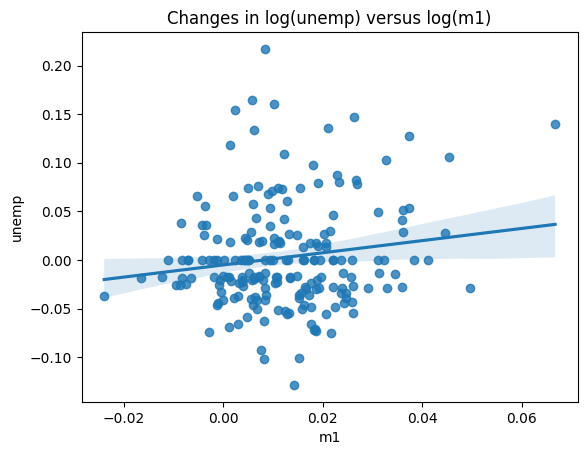

```python
# Generate scatter plot with regression line
fig = sns.regplot(x='m1', y='unemp', data=trans_data)

# Add a descriptive title that summarizes the plot's content
fig.set(title='Changes in log(unemp) versus log(m1)');
```

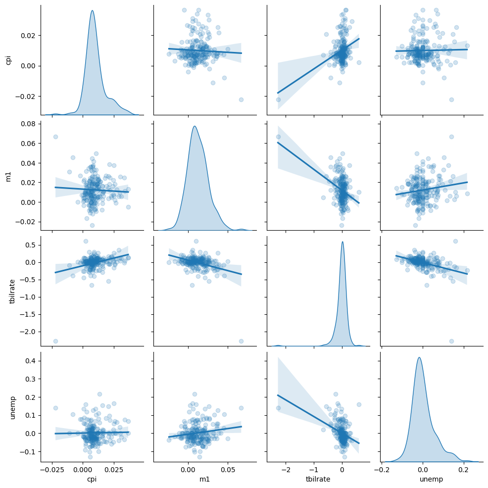

```python
# kde = kernel density estimate - another name for density plot
# Estimate of the continuous probability distribution
sns.pairplot(trans_data, diag_kind='kde', kind='reg',
             plot_kws={'scatter_kws': {'alpha': 0.2}});
```

### **Facet Grids and Categorical Data**

visualize data with many **categorical variables**

Seaborn **catplot** function simplifies making many kinds of faceted plots split by **categorical variables**

**faceted** means having many sides

```python
# Display contents for tips dataframe
tips
```

|  | total_bill | tip | smoker | day | time | size | tip_pct |
| --- | --- | --- | --- | --- | --- | --- | --- |
| 0 | 16.99 | 1.01 | No | Sun | Dinner | 2 | 0.063204 |
| 1 | 10.34 | 1.66 | No | Sun | Dinner | 3 | 0.191244 |
| 2 | 21.01 | 3.50 | No | Sun | Dinner | 3 | 0.199886 |
| 3 | 23.68 | 3.31 | No | Sun | Dinner | 2 | 0.162494 |
| 4 | 24.59 | 3.61 | No | Sun | Dinner | 4 | 0.172069 |
| ... | ... | ... | ... | ... | ... | ... | ... |
| 239 | 29.03 | 5.92 | No | Sat | Dinner | 3 | 0.256166 |
| 240 | 27.18 | 2.00 | Yes | Sat | Dinner | 2 | 0.079428 |
| 241 | 22.67 | 2.00 | Yes | Sat | Dinner | 2 | 0.096759 |
| 242 | 17.82 | 1.75 | No | Sat | Dinner | 2 | 0.108899 |
| 243 | 18.78 | 3.00 | No | Thur | Dinner | 2 | 0.190114 |

244 rows × 7 columns

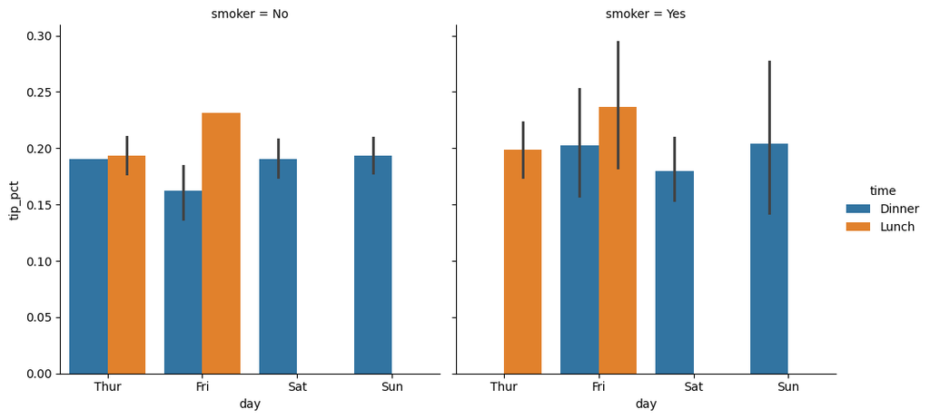

```python
# Generate categorical plot
sns.catplot(x='day', y='tip_pct', hue='time', col='smoker',
            kind='bar', data=tips[tips.tip_pct < 1],
            order=['Thur', 'Fri', 'Sat', 'Sun']);
```

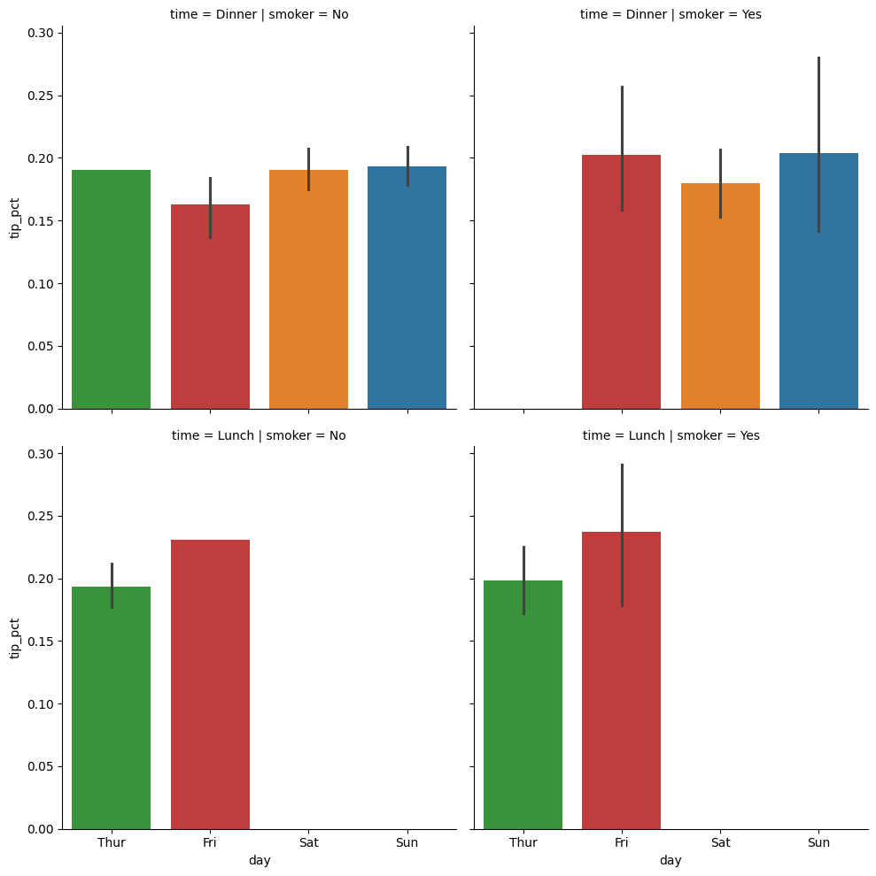

```python
# Generate categorical plot
sns.catplot(x='day', y='tip_pct', row='time',
            col='smoker', hue='day', order=['Thur', 'Fri', 'Sat', 'Sun'],
            kind='bar', data=tips[tips.tip_pct < 1]);
```

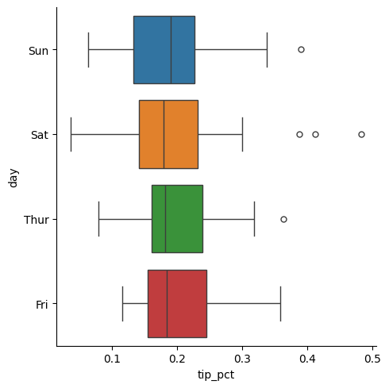

```python
# Generate categorical plot: boxplot
sns.catplot(x='tip_pct', y='day', hue='day', kind='box',
            data=tips[tips.tip_pct < 0.5]);
```

# **That's it for the day!!! :)**

## **Please join this Whatsapp group for general communication and updates**

[figure not shown]